# Jak uzupełnić brakujące dane w dataframe Python?

#### Linear Regression model in Python Sklearn part 1 [Polish Version]

## Baza danych: AirQualityUCI

# Jak uzupełnić brakujące dane w dataframe Python?

```python
import pandas as pd
df = pd.read_csv('c:/TS/AirQualityUCI.csv', sep=';')
df.head(3)
```

|  | Date | Time | CO(GT) | PT08.S1(CO) | NMHC(GT) | C6H6(GT) | PT08.S2(NMHC) | NOx(GT) | PT08.S3(NOx) | NO2(GT) | PT08.S4(NO2) | PT08.S5(O3) | T | RH | AH | Unnamed: 15 | Unnamed: 16 |
| --- | --- | --- | --- | --- | --- | --- | --- | --- | --- | --- | --- | --- | --- | --- | --- | --- | --- |
| 0 | 10/03/2004 | 18.00.00 | 2,6 | 1360.0 | 150.0 | 11,9 | 1046.0 | 166.0 | 1056.0 | 113.0 | 1692.0 | 1268.0 | 13,6 | 48,9 | 0,7578 | NaN | NaN |
| 1 | 10/03/2004 | 19.00.00 | 2 | 1292.0 | 112.0 | 9,4 | 955.0 | 103.0 | 1174.0 | 92.0 | 1559.0 | 972.0 | 13,3 | 47,7 | 0,7255 | NaN | NaN |
| 2 | 10/03/2004 | 20.00.00 | 2,2 | 1402.0 | 88.0 | 9,0 | 939.0 | 131.0 | 1140.0 | 114.0 | 1555.0 | 1074.0 | 11,9 | 54,0 | 0,7502 | NaN | NaN |

## AirQualityUCI

Source of data: https://archive.ics.uci.edu/ml/datasets/Air+Quality

Jak uzupełnić brakujące dane w dataframe Python?

### Informacje o zestawie danych:

Zestaw danych zawiera 9358 wystąpień uśrednionych co godzinę odpowiedzi z szeregu 5 czujników chemicznych tlenków metali osadzonych w wieloczujnikowym urządzeniu chemicznym jakości powietrza. Urządzenie znajdowało się na polu, w bardzo zanieczyszczonym obszarze, na poziomie drogi, w włoskim mieście. Dane były rejestrowane od marca 2004 r. Do lutego 2005 r. (Jeden rok), reprezentując najdłuższe i swobodnie dostępne zapisy odpowiedzi czujników chemicznych jakości powietrza rozmieszczonych w terenie. Uśrednione co godzinę uśrednione stężenia prawdy dla CO, węglowodorów niemetanowych, benzenu, tlenków azotu ogółem (NOx) i dwutlenku azotu (NO2) i zostały dostarczone przez certyfikowany analizator referencyjny z tej samej lokalizacji. Dowody wrażliwości krzyżowej, jak również dryftu koncepcji i czujnika są obecne, jak opisano w De Vito i in., Sens. I Act. B, t. 129,2, 2008 (wymagany cytat) ostatecznie wpływa na możliwości szacowania stężeń czujników. Brakujące wartości są oznaczone wartością -200.

Jak uzupełnić brakujące dane w dataframe Python?

### Informacje o atrybucie:

```
0 Date
1 Time, Czas (GG.MM.SS)
2 CO(GT) Rzeczywiste uśrednione godzinne stężenie CO w mg / m ^ 3 (analizator referencyjny)
3 PT08.S1 (tlenek cyny) uśredniona co godzinę reakcja czujnika (nominalnie ukierunkowana na CO )
4 NMHC(GT) Rzeczywiste uśrednione godzinne ogólne stężenie węglowodorów niemetanicznych w mikrog / m ^ 3 (analizator referencyjny)
5 C6H6(GT) Rzeczywiste uśrednione godzinne stężenie benzenu w mikrog / m ^ 3 (analizator referencyjny)
6 PT08.S2(NMHC) (Tytania) uśredniona co godzinę reakcja czujnika (nominalnie NMHC ukierunkowane)
7 NOx(GT) Rzeczywiste uśrednione godzinne stężenie NOx w ppb (analizator referencyjny)
8 PT08.S3(NOx) (tlenek wolframu) uśredniona co godzinę odpowiedź czujnika (nominalnie ukierunkowane na NOx)
9 NO2(GT) Prawdziwie uśrednione godzinne stężenie NO2 w mikrog / m ^ 3 (analizator referencyjny)
10 PT08.S4(NO2) (tlenek wolframu) uśredniona godzinowo reakcja czujnika (nominalnie ukierunkowane na NO2)
11 PT08.S5(O3) (tlenek indu) godzinna uśredniona reakcja czujnika (nominalnie ukierunkowane na O3)
12 T Temperatura w ° C
13 RH Wilgotność względna (%)
14 AH Wilgotność bezwzględna
```

Sprawdzamy kompletność danych

```python
df.isnull().sum()
```

```
Date              114
Time              114
CO(GT)            114
PT08.S1(CO)       114
NMHC(GT)          114
C6H6(GT)          114
PT08.S2(NMHC)     114
NOx(GT)           114
PT08.S3(NOx)      114
NO2(GT)           114
PT08.S4(NO2)      114
PT08.S5(O3)       114
T                 114
RH                114
AH                114
Unnamed: 15      9471
Unnamed: 16      9471
dtype: int64
```

```python
#df = df.dropna(how='any')
#df.isnull().sum()
```

```python
df.head()
```

|  | Date | Time | CO(GT) | PT08.S1(CO) | NMHC(GT) | C6H6(GT) | PT08.S2(NMHC) | NOx(GT) | PT08.S3(NOx) | NO2(GT) | PT08.S4(NO2) | PT08.S5(O3) | T | RH | AH | Unnamed: 15 | Unnamed: 16 |
| --- | --- | --- | --- | --- | --- | --- | --- | --- | --- | --- | --- | --- | --- | --- | --- | --- | --- |
| 0 | 10/03/2004 | 18.00.00 | 2,6 | 1360.0 | 150.0 | 11,9 | 1046.0 | 166.0 | 1056.0 | 113.0 | 1692.0 | 1268.0 | 13,6 | 48,9 | 0,7578 | NaN | NaN |
| 1 | 10/03/2004 | 19.00.00 | 2 | 1292.0 | 112.0 | 9,4 | 955.0 | 103.0 | 1174.0 | 92.0 | 1559.0 | 972.0 | 13,3 | 47,7 | 0,7255 | NaN | NaN |
| 2 | 10/03/2004 | 20.00.00 | 2,2 | 1402.0 | 88.0 | 9,0 | 939.0 | 131.0 | 1140.0 | 114.0 | 1555.0 | 1074.0 | 11,9 | 54,0 | 0,7502 | NaN | NaN |
| 3 | 10/03/2004 | 21.00.00 | 2,2 | 1376.0 | 80.0 | 9,2 | 948.0 | 172.0 | 1092.0 | 122.0 | 1584.0 | 1203.0 | 11,0 | 60,0 | 0,7867 | NaN | NaN |
| 4 | 10/03/2004 | 22.00.00 | 1,6 | 1272.0 | 51.0 | 6,5 | 836.0 | 131.0 | 1205.0 | 116.0 | 1490.0 | 1110.0 | 11,2 | 59,6 | 0,7888 | NaN | NaN |

```python
df.shape
```

```
(9471, 17)
```

```python
del df['Unnamed: 15']
del df['Unnamed: 16']
```

```python
df.isnull().sum()
```

```
Date             114
Time             114
CO(GT)           114
PT08.S1(CO)      114
NMHC(GT)         114
C6H6(GT)         114
PT08.S2(NMHC)    114
NOx(GT)          114
PT08.S3(NOx)     114
NO2(GT)          114
PT08.S4(NO2)     114
PT08.S5(O3)      114
T                114
RH               114
AH               114
dtype: int64
```

```python
df[df['NMHC(GT)'].isnull()]
```

|  | Date | Time | CO(GT) | PT08.S1(CO) | NMHC(GT) | C6H6(GT) | PT08.S2(NMHC) | NOx(GT) | PT08.S3(NOx) | NO2(GT) | PT08.S4(NO2) | PT08.S5(O3) | T | RH | AH |
| --- | --- | --- | --- | --- | --- | --- | --- | --- | --- | --- | --- | --- | --- | --- | --- |
| 9357 | NaN | NaN | NaN | NaN | NaN | NaN | NaN | NaN | NaN | NaN | NaN | NaN | NaN | NaN | NaN |
| 9358 | NaN | NaN | NaN | NaN | NaN | NaN | NaN | NaN | NaN | NaN | NaN | NaN | NaN | NaN | NaN |
| 9359 | NaN | NaN | NaN | NaN | NaN | NaN | NaN | NaN | NaN | NaN | NaN | NaN | NaN | NaN | NaN |
| 9360 | NaN | NaN | NaN | NaN | NaN | NaN | NaN | NaN | NaN | NaN | NaN | NaN | NaN | NaN | NaN |
| 9361 | NaN | NaN | NaN | NaN | NaN | NaN | NaN | NaN | NaN | NaN | NaN | NaN | NaN | NaN | NaN |
| 9362 | NaN | NaN | NaN | NaN | NaN | NaN | NaN | NaN | NaN | NaN | NaN | NaN | NaN | NaN | NaN |
| 9363 | NaN | NaN | NaN | NaN | NaN | NaN | NaN | NaN | NaN | NaN | NaN | NaN | NaN | NaN | NaN |
| 9364 | NaN | NaN | NaN | NaN | NaN | NaN | NaN | NaN | NaN | NaN | NaN | NaN | NaN | NaN | NaN |
| 9365 | NaN | NaN | NaN | NaN | NaN | NaN | NaN | NaN | NaN | NaN | NaN | NaN | NaN | NaN | NaN |
| 9366 | NaN | NaN | NaN | NaN | NaN | NaN | NaN | NaN | NaN | NaN | NaN | NaN | NaN | NaN | NaN |
| 9367 | NaN | NaN | NaN | NaN | NaN | NaN | NaN | NaN | NaN | NaN | NaN | NaN | NaN | NaN | NaN |
| 9368 | NaN | NaN | NaN | NaN | NaN | NaN | NaN | NaN | NaN | NaN | NaN | NaN | NaN | NaN | NaN |
| 9369 | NaN | NaN | NaN | NaN | NaN | NaN | NaN | NaN | NaN | NaN | NaN | NaN | NaN | NaN | NaN |
| 9370 | NaN | NaN | NaN | NaN | NaN | NaN | NaN | NaN | NaN | NaN | NaN | NaN | NaN | NaN | NaN |
| 9371 | NaN | NaN | NaN | NaN | NaN | NaN | NaN | NaN | NaN | NaN | NaN | NaN | NaN | NaN | NaN |
| 9372 | NaN | NaN | NaN | NaN | NaN | NaN | NaN | NaN | NaN | NaN | NaN | NaN | NaN | NaN | NaN |
| 9373 | NaN | NaN | NaN | NaN | NaN | NaN | NaN | NaN | NaN | NaN | NaN | NaN | NaN | NaN | NaN |
| 9374 | NaN | NaN | NaN | NaN | NaN | NaN | NaN | NaN | NaN | NaN | NaN | NaN | NaN | NaN | NaN |
| 9375 | NaN | NaN | NaN | NaN | NaN | NaN | NaN | NaN | NaN | NaN | NaN | NaN | NaN | NaN | NaN |
| 9376 | NaN | NaN | NaN | NaN | NaN | NaN | NaN | NaN | NaN | NaN | NaN | NaN | NaN | NaN | NaN |
| 9377 | NaN | NaN | NaN | NaN | NaN | NaN | NaN | NaN | NaN | NaN | NaN | NaN | NaN | NaN | NaN |
| 9378 | NaN | NaN | NaN | NaN | NaN | NaN | NaN | NaN | NaN | NaN | NaN | NaN | NaN | NaN | NaN |
| 9379 | NaN | NaN | NaN | NaN | NaN | NaN | NaN | NaN | NaN | NaN | NaN | NaN | NaN | NaN | NaN |
| 9380 | NaN | NaN | NaN | NaN | NaN | NaN | NaN | NaN | NaN | NaN | NaN | NaN | NaN | NaN | NaN |
| 9381 | NaN | NaN | NaN | NaN | NaN | NaN | NaN | NaN | NaN | NaN | NaN | NaN | NaN | NaN | NaN |
| 9382 | NaN | NaN | NaN | NaN | NaN | NaN | NaN | NaN | NaN | NaN | NaN | NaN | NaN | NaN | NaN |
| 9383 | NaN | NaN | NaN | NaN | NaN | NaN | NaN | NaN | NaN | NaN | NaN | NaN | NaN | NaN | NaN |
| 9384 | NaN | NaN | NaN | NaN | NaN | NaN | NaN | NaN | NaN | NaN | NaN | NaN | NaN | NaN | NaN |
| 9385 | NaN | NaN | NaN | NaN | NaN | NaN | NaN | NaN | NaN | NaN | NaN | NaN | NaN | NaN | NaN |
| 9386 | NaN | NaN | NaN | NaN | NaN | NaN | NaN | NaN | NaN | NaN | NaN | NaN | NaN | NaN | NaN |
| ... | ... | ... | ... | ... | ... | ... | ... | ... | ... | ... | ... | ... | ... | ... | ... |
| 9441 | NaN | NaN | NaN | NaN | NaN | NaN | NaN | NaN | NaN | NaN | NaN | NaN | NaN | NaN | NaN |
| 9442 | NaN | NaN | NaN | NaN | NaN | NaN | NaN | NaN | NaN | NaN | NaN | NaN | NaN | NaN | NaN |
| 9443 | NaN | NaN | NaN | NaN | NaN | NaN | NaN | NaN | NaN | NaN | NaN | NaN | NaN | NaN | NaN |
| 9444 | NaN | NaN | NaN | NaN | NaN | NaN | NaN | NaN | NaN | NaN | NaN | NaN | NaN | NaN | NaN |
| 9445 | NaN | NaN | NaN | NaN | NaN | NaN | NaN | NaN | NaN | NaN | NaN | NaN | NaN | NaN | NaN |
| 9446 | NaN | NaN | NaN | NaN | NaN | NaN | NaN | NaN | NaN | NaN | NaN | NaN | NaN | NaN | NaN |
| 9447 | NaN | NaN | NaN | NaN | NaN | NaN | NaN | NaN | NaN | NaN | NaN | NaN | NaN | NaN | NaN |
| 9448 | NaN | NaN | NaN | NaN | NaN | NaN | NaN | NaN | NaN | NaN | NaN | NaN | NaN | NaN | NaN |
| 9449 | NaN | NaN | NaN | NaN | NaN | NaN | NaN | NaN | NaN | NaN | NaN | NaN | NaN | NaN | NaN |
| 9450 | NaN | NaN | NaN | NaN | NaN | NaN | NaN | NaN | NaN | NaN | NaN | NaN | NaN | NaN | NaN |
| 9451 | NaN | NaN | NaN | NaN | NaN | NaN | NaN | NaN | NaN | NaN | NaN | NaN | NaN | NaN | NaN |
| 9452 | NaN | NaN | NaN | NaN | NaN | NaN | NaN | NaN | NaN | NaN | NaN | NaN | NaN | NaN | NaN |
| 9453 | NaN | NaN | NaN | NaN | NaN | NaN | NaN | NaN | NaN | NaN | NaN | NaN | NaN | NaN | NaN |
| 9454 | NaN | NaN | NaN | NaN | NaN | NaN | NaN | NaN | NaN | NaN | NaN | NaN | NaN | NaN | NaN |
| 9455 | NaN | NaN | NaN | NaN | NaN | NaN | NaN | NaN | NaN | NaN | NaN | NaN | NaN | NaN | NaN |
| 9456 | NaN | NaN | NaN | NaN | NaN | NaN | NaN | NaN | NaN | NaN | NaN | NaN | NaN | NaN | NaN |
| 9457 | NaN | NaN | NaN | NaN | NaN | NaN | NaN | NaN | NaN | NaN | NaN | NaN | NaN | NaN | NaN |
| 9458 | NaN | NaN | NaN | NaN | NaN | NaN | NaN | NaN | NaN | NaN | NaN | NaN | NaN | NaN | NaN |
| 9459 | NaN | NaN | NaN | NaN | NaN | NaN | NaN | NaN | NaN | NaN | NaN | NaN | NaN | NaN | NaN |
| 9460 | NaN | NaN | NaN | NaN | NaN | NaN | NaN | NaN | NaN | NaN | NaN | NaN | NaN | NaN | NaN |
| 9461 | NaN | NaN | NaN | NaN | NaN | NaN | NaN | NaN | NaN | NaN | NaN | NaN | NaN | NaN | NaN |
| 9462 | NaN | NaN | NaN | NaN | NaN | NaN | NaN | NaN | NaN | NaN | NaN | NaN | NaN | NaN | NaN |
| 9463 | NaN | NaN | NaN | NaN | NaN | NaN | NaN | NaN | NaN | NaN | NaN | NaN | NaN | NaN | NaN |
| 9464 | NaN | NaN | NaN | NaN | NaN | NaN | NaN | NaN | NaN | NaN | NaN | NaN | NaN | NaN | NaN |
| 9465 | NaN | NaN | NaN | NaN | NaN | NaN | NaN | NaN | NaN | NaN | NaN | NaN | NaN | NaN | NaN |
| 9466 | NaN | NaN | NaN | NaN | NaN | NaN | NaN | NaN | NaN | NaN | NaN | NaN | NaN | NaN | NaN |
| 9467 | NaN | NaN | NaN | NaN | NaN | NaN | NaN | NaN | NaN | NaN | NaN | NaN | NaN | NaN | NaN |
| 9468 | NaN | NaN | NaN | NaN | NaN | NaN | NaN | NaN | NaN | NaN | NaN | NaN | NaN | NaN | NaN |
| 9469 | NaN | NaN | NaN | NaN | NaN | NaN | NaN | NaN | NaN | NaN | NaN | NaN | NaN | NaN | NaN |
| 9470 | NaN | NaN | NaN | NaN | NaN | NaN | NaN | NaN | NaN | NaN | NaN | NaN | NaN | NaN | NaN |

114 rows × 15 columns

```python
df = df.dropna(how='all')
df.isnull().sum()
```

```
Date             0
Time             0
CO(GT)           0
PT08.S1(CO)      0
NMHC(GT)         0
C6H6(GT)         0
PT08.S2(NMHC)    0
NOx(GT)          0
PT08.S3(NOx)     0
NO2(GT)          0
PT08.S4(NO2)     0
PT08.S5(O3)      0
T                0
RH               0
AH               0
dtype: int64
```

Szukamy zmiennych o wartości -200 ponieważ to oznacza, że nie ma tam danych.

```python
import numpy as np

df = df.replace(-200,np.NaN)
df = df.replace('-200',np.NaN)
df = df.replace('-200.0',np.NaN)
df = df.replace('-200,0',np.NaN)
```

```python
df.isnull().sum()
```

```
Date                0
Time                0
CO(GT)           1683
PT08.S1(CO)       366
NMHC(GT)         8443
C6H6(GT)          366
PT08.S2(NMHC)     366
NOx(GT)          1639
PT08.S3(NOx)      366
NO2(GT)          1642
PT08.S4(NO2)      366
PT08.S5(O3)       366
T                 366
RH                366
AH                366
dtype: int64
```

```python
import seaborn as sns

sns.heatmap(df.isnull(),yticklabels=False,cbar=False,cmap='viridis')
```

[output not shown]

Zmienna NMHC(GT) jest najbardziej niekompletna eliminujemy ją z badań

```python
del df['NMHC(GT)']
```

Wyświetlamy rekordy z brakującymi danymi Funkcja isna()

```python
df1 = df[df.isna().any(axis=1)]
df1
```

|  | Date | Time | CO(GT) | PT08.S1(CO) | C6H6(GT) | PT08.S2(NMHC) | NOx(GT) | PT08.S3(NOx) | NO2(GT) | PT08.S4(NO2) | PT08.S5(O3) | T | RH | AH |
| --- | --- | --- | --- | --- | --- | --- | --- | --- | --- | --- | --- | --- | --- | --- |
| 9 | 11/03/2004 | 03.00.00 | 0,6 | 1010.0 | 1,7 | 561.0 | NaN | 1705.0 | NaN | 1235.0 | 501.0 | 10,3 | 60,2 | 0,7517 |
| 10 | 11/03/2004 | 04.00.00 | NaN | 1011.0 | 1,3 | 527.0 | 21.0 | 1818.0 | 34.0 | 1197.0 | 445.0 | 10,1 | 60,5 | 0,7465 |
| 33 | 12/03/2004 | 03.00.00 | 0,8 | 889.0 | 1,9 | 574.0 | NaN | 1680.0 | NaN | 1187.0 | 512.0 | 7,0 | 62,3 | 0,6261 |
| 34 | 12/03/2004 | 04.00.00 | NaN | 831.0 | 1,1 | 506.0 | 21.0 | 1893.0 | 32.0 | 1134.0 | 384.0 | 6,1 | 65,9 | 0,6248 |
| 39 | 12/03/2004 | 09.00.00 | NaN | 1545.0 | 22,1 | 1353.0 | NaN | 767.0 | NaN | 2058.0 | 1588.0 | 9,2 | 56,2 | 0,6561 |
| 57 | 13/03/2004 | 03.00.00 | 1,7 | 1172.0 | 5,4 | 783.0 | NaN | 1179.0 | NaN | 1380.0 | 996.0 | 7,8 | 67,5 | 0,7173 |
| 58 | 13/03/2004 | 04.00.00 | NaN | 1147.0 | 6,2 | 821.0 | 109.0 | 1132.0 | 83.0 | 1412.0 | 992.0 | 7,0 | 71,1 | 0,7158 |
| 81 | 14/03/2004 | 03.00.00 | 2,4 | 1344.0 | 9,7 | 968.0 | NaN | 921.0 | NaN | 1620.0 | 1278.0 | 11,6 | 63,4 | 0,8674 |
| 82 | 14/03/2004 | 04.00.00 | NaN | 1130.0 | 5,2 | 773.0 | 70.0 | 1130.0 | 82.0 | 1452.0 | 1051.0 | 12,1 | 61,1 | 0,8603 |
| 105 | 15/03/2004 | 03.00.00 | 1,1 | 1078.0 | 4,4 | 734.0 | NaN | 1128.0 | NaN | 1487.0 | 1021.0 | 12,6 | 63,5 | 0,9230 |
| 106 | 15/03/2004 | 04.00.00 | NaN | 1078.0 | 4,0 | 711.0 | 66.0 | 1150.0 | 71.0 | 1468.0 | 1013.0 | 12,3 | 65,4 | 0,9351 |
| 129 | 16/03/2004 | 03.00.00 | 0,7 | 929.0 | 2,3 | 608.0 | NaN | 1376.0 | NaN | 1364.0 | 826.0 | 13,6 | 62,1 | 0,9636 |
| 130 | 16/03/2004 | 04.00.00 | NaN | 941.0 | 2,6 | 626.0 | 59.0 | 1316.0 | 59.0 | 1373.0 | 840.0 | 12,3 | 66,2 | 0,9450 |
| 153 | 17/03/2004 | 03.00.00 | 0,7 | 933.0 | 2,6 | 625.0 | NaN | 1292.0 | NaN | 1332.0 | 884.0 | 13,1 | 57,9 | 0,8666 |
| 154 | 17/03/2004 | 04.00.00 | NaN | 883.0 | 1,9 | 577.0 | 54.0 | 1396.0 | 60.0 | 1303.0 | 808.0 | 12,7 | 57,9 | 0,8447 |
| 177 | 18/03/2004 | 03.00.00 | 0,7 | 970.0 | 3,6 | 687.0 | NaN | 1196.0 | NaN | 1351.0 | 969.0 | 13,9 | 53,9 | 0,8501 |
| 178 | 18/03/2004 | 04.00.00 | NaN | 954.0 | 2,9 | 645.0 | 60.0 | 1260.0 | 78.0 | 1334.0 | 925.0 | 11,6 | 61,9 | 0,8442 |
| 201 | 19/03/2004 | 03.00.00 | 0,7 | 961.0 | 2,5 | 622.0 | NaN | 1382.0 | NaN | 1301.0 | 430.0 | 12,5 | 67,5 | 0,9768 |
| 202 | 19/03/2004 | 04.00.00 | NaN | 934.0 | 1,8 | 569.0 | 20.0 | 1440.0 | 32.0 | 1280.0 | 397.0 | 12,3 | 67,7 | 0,9665 |
| 225 | 20/03/2004 | 03.00.00 | 1,3 | 997.0 | 3,4 | 677.0 | NaN | 1252.0 | NaN | 1359.0 | 591.0 | 13,8 | 55,1 | 0,8666 |
| 226 | 20/03/2004 | 04.00.00 | NaN | 945.0 | 2,9 | 646.0 | 44.0 | 1308.0 | 55.0 | 1332.0 | 505.0 | 13,8 | 54,6 | 0,8574 |
| 249 | 21/03/2004 | 03.00.00 | 1,6 | 1195.0 | 6,5 | 836.0 | NaN | 987.0 | NaN | 1554.0 | 885.0 | 15,2 | 57,9 | 0,9941 |
| 250 | 21/03/2004 | 04.00.00 | NaN | 1117.0 | 5,8 | 802.0 | 85.0 | 1029.0 | 87.0 | 1539.0 | 818.0 | 15,4 | 57,8 | 1,0021 |
| 273 | 22/03/2004 | 03.00.00 | 0,4 | 842.0 | 0,7 | 468.0 | NaN | 1813.0 | NaN | 1274.0 | 394.0 | 16,9 | 53,9 | 1,0309 |
| 274 | 22/03/2004 | 04.00.00 | NaN | 854.0 | 0,8 | 481.0 | 17.0 | 1756.0 | 27.0 | 1304.0 | 396.0 | 16,1 | 55,9 | 1,0153 |
| 297 | 23/03/2004 | 03.00.00 | 0,5 | 892.0 | 1,2 | 522.0 | NaN | 1522.0 | NaN | 1285.0 | 456.0 | 11,0 | 70,0 | 0,9215 |
| 298 | 23/03/2004 | 04.00.00 | NaN | 855.0 | 0,8 | 478.0 | 20.0 | 1701.0 | 31.0 | 1261.0 | 401.0 | 10,1 | 76,8 | 0,9483 |
| 321 | 24/03/2004 | 03.00.00 | 0,6 | 878.0 | 1,6 | 551.0 | NaN | 1493.0 | NaN | 1272.0 | 683.0 | 10,6 | 61,6 | 0,7856 |
| 322 | 24/03/2004 | 04.00.00 | NaN | 908.0 | 1,7 | 559.0 | 44.0 | 1477.0 | 66.0 | 1287.0 | 721.0 | 10,2 | 62,7 | 0,7813 |
| 333 | 24/03/2004 | 15.00.00 | NaN | 1112.0 | 6,7 | 842.0 | 100.0 | 1015.0 | 91.0 | 1494.0 | 680.0 | 11,3 | 63,9 | 0,8554 |
| ... | ... | ... | ... | ... | ... | ... | ... | ... | ... | ... | ... | ... | ... | ... |
| 8601 | 04/03/2005 | 03.00.00 | 1,2 | 982.0 | 2,5 | 617.0 | NaN | 891.0 | NaN | 977.0 | 1024.0 | 4,5 | 70,6 | 0,6004 |
| 8625 | 05/03/2005 | 03.00.00 | 1,5 | 1041.0 | 4,4 | 732.0 | NaN | 789.0 | NaN | 1003.0 | 1076.0 | 4,9 | 62,6 | 0,5477 |
| 8626 | 05/03/2005 | 04.00.00 | NaN | 1009.0 | 4,0 | 710.0 | 191.0 | 819.0 | 136.0 | 974.0 | 1011.0 | 4,4 | 63,9 | 0,5385 |
| 8649 | 06/03/2005 | 03.00.00 | 0,8 | 856.0 | 1,5 | 545.0 | NaN | 1166.0 | NaN | 803.0 | 398.0 | 7,2 | 47,3 | 0,4830 |
| 8673 | 07/03/2005 | 03.00.00 | 0,6 | 841.0 | 0,7 | 470.0 | NaN | 1311.0 | NaN | 708.0 | 289.0 | 5,3 | 51,0 | 0,4563 |
| 8697 | 08/03/2005 | 03.00.00 | 0,8 | 876.0 | 1,9 | 576.0 | NaN | 1040.0 | NaN | 815.0 | 900.0 | 1,0 | 56,7 | 0,3803 |
| 8698 | 08/03/2005 | 04.00.00 | NaN | 872.0 | 1,7 | 558.0 | 114.0 | 1054.0 | 101.0 | 807.0 | 853.0 | 0,5 | 59,4 | 0,3841 |
| 8721 | 09/03/2005 | 03.00.00 | 0,8 | 937.0 | 2,2 | 600.0 | NaN | 985.0 | NaN | 873.0 | 885.0 | 4,7 | 53,1 | 0,4589 |
| 8745 | 10/03/2005 | 03.00.00 | 1,1 | 1014.0 | 4,4 | 731.0 | NaN | 784.0 | NaN | 1062.0 | 1038.0 | 4,6 | 78,2 | 0,6684 |
| 8755 | 10/03/2005 | 13.00.00 | 2,3 | 1176.0 | 9,8 | 969.0 | NaN | 612.0 | NaN | 1196.0 | 1300.0 | 18,8 | 26,2 | 0,5637 |
| 8770 | 11/03/2005 | 04.00.00 | NaN | 942.0 | 3,2 | 665.0 | 134.0 | 923.0 | 91.0 | 912.0 | 956.0 | 4,4 | 56,4 | 0,4761 |
| 8777 | 11/03/2005 | 11.00.00 | 3,0 | NaN | NaN | NaN | 812.0 | NaN | 235.0 | NaN | NaN | NaN | NaN | NaN |
| 8794 | 12/03/2005 | 04.00.00 | NaN | 1015.0 | 2,3 | 608.0 | 113.0 | 873.0 | 85.0 | 1027.0 | 655.0 | 10,3 | 59,4 | 0,7459 |
| 8795 | 12/03/2005 | 05.00.00 | NaN | 979.0 | 1,5 | 547.0 | 73.0 | 952.0 | 55.0 | 1039.0 | 470.0 | 9,8 | 68,9 | 0,8329 |
| 8796 | 12/03/2005 | 06.00.00 | NaN | 972.0 | 1,5 | 542.0 | 103.0 | 1029.0 | 65.0 | 1056.0 | 443.0 | 9,2 | 75,3 | 0,8764 |
| 8797 | 12/03/2005 | 07.00.00 | NaN | 992.0 | 1,8 | 565.0 | 121.0 | 912.0 | 84.0 | 1074.0 | 547.0 | 9,4 | 73,1 | 0,8621 |
| 8817 | 13/03/2005 | 03.00.00 | NaN | 940.0 | 2,0 | 583.0 | 93.0 | 942.0 | 69.0 | 991.0 | 416.0 | 12,7 | 51,8 | 0,7574 |
| 8818 | 13/03/2005 | 04.00.00 | NaN | 963.0 | 2,5 | 617.0 | 85.0 | 902.0 | 63.0 | 1006.0 | 398.0 | 13,2 | 49,7 | 0,7503 |
| 8819 | 13/03/2005 | 05.00.00 | NaN | 971.0 | 2,0 | 585.0 | 79.0 | 928.0 | 61.0 | 1004.0 | 394.0 | 12,3 | 55,9 | 0,7966 |
| 8820 | 13/03/2005 | 06.00.00 | NaN | 887.0 | 0,9 | 488.0 | 55.0 | 1184.0 | 42.0 | 908.0 | 312.0 | 13,3 | 50,1 | 0,7624 |
| 8821 | 13/03/2005 | 07.00.00 | NaN | 944.0 | 1,6 | 551.0 | 98.0 | 1063.0 | 68.0 | 985.0 | 381.0 | 12,3 | 51,8 | 0,7384 |
| 8822 | 13/03/2005 | 08.00.00 | NaN | 970.0 | 2,1 | 592.0 | 190.0 | 909.0 | 120.0 | 1018.0 | 509.0 | 12,9 | 50,4 | 0,7448 |
| 8842 | 14/03/2005 | 04.00.00 | NaN | 1036.0 | 2,8 | 636.0 | 122.0 | 845.0 | 90.0 | 1084.0 | 976.0 | 8,9 | 71,9 | 0,8202 |
| 8914 | 17/03/2005 | 04.00.00 | NaN | 959.0 | 1,9 | 578.0 | 100.0 | 909.0 | 81.0 | 1016.0 | 822.0 | 10,1 | 61,9 | 0,7631 |
| 8986 | 20/03/2005 | 04.00.00 | NaN | 993.0 | 2,8 | 640.0 | 85.0 | 848.0 | 66.0 | 1110.0 | 548.0 | 13,0 | 65,3 | 0,9704 |
| 9058 | 23/03/2005 | 04.00.00 | NaN | 993.0 | 2,3 | 604.0 | 85.0 | 848.0 | 65.0 | 1160.0 | 762.0 | 14,5 | 66,4 | 1,0919 |
| 9130 | 26/03/2005 | 04.00.00 | NaN | 1122.0 | 6,0 | 811.0 | 181.0 | 641.0 | 92.0 | 1336.0 | 1122.0 | 16,2 | 71,2 | 1,3013 |
| 9202 | 29/03/2005 | 04.00.00 | NaN | 883.0 | 1,3 | 530.0 | 63.0 | 997.0 | 46.0 | 1102.0 | 617.0 | 13,7 | 68,2 | 1,0611 |
| 9274 | 01/04/2005 | 04.00.00 | NaN | 818.0 | 0,8 | 473.0 | 47.0 | 1257.0 | 41.0 | 898.0 | 323.0 | 13,7 | 48,8 | 0,7606 |
| 9346 | 04/04/2005 | 04.00.00 | NaN | 864.0 | 0,8 | 478.0 | 52.0 | 1116.0 | 43.0 | 958.0 | 489.0 | 11,8 | 56,0 | 0,7743 |

2416 rows × 14 columns

CO(GT) brakuje tam danych co kilka pomiarów, trzeba sprawdzić z czy się ta zmiennna koreluje

```python
df.dtypes
```

```
Date              object
Time              object
CO(GT)            object
PT08.S1(CO)      float64
C6H6(GT)          object
PT08.S2(NMHC)    float64
NOx(GT)          float64
PT08.S3(NOx)     float64
NO2(GT)          float64
PT08.S4(NO2)     float64
PT08.S5(O3)      float64
T                 object
RH                object
AH                object
dtype: object
```

```python
# df['CO(GT)'].astype(float)
```

Zamieniamy przecinki na kropki

```python
df['CO(GT)'] = df['CO(GT)'].str.replace(',','.')
df['C6H6(GT)'] = df['C6H6(GT)'].str.replace(',','.')
df['T'] = df['T'].str.replace(',','.')
df['RH'] = df['RH'].str.replace(',','.')
df['AH'] = df['AH'].str.replace(',','.')
```

Zmieniamy format z object na float

```python
df[['CO(GT)','C6H6(GT)', 'T','RH','AH']] = df[['CO(GT)','C6H6(GT)', 'T','RH','AH']].astype(float)
```

```python
df.dtypes
```

```
Date              object
Time              object
CO(GT)           float64
PT08.S1(CO)      float64
C6H6(GT)         float64
PT08.S2(NMHC)    float64
NOx(GT)          float64
PT08.S3(NOx)     float64
NO2(GT)          float64
PT08.S4(NO2)     float64
PT08.S5(O3)      float64
T                float64
RH               float64
AH               float64
dtype: object
```

Teraz możemy sprawdzić poziom korelacji bezpośredniej

```python
df.corr()
```

|  | CO(GT) | PT08.S1(CO) | C6H6(GT) | PT08.S2(NMHC) | NOx(GT) | PT08.S3(NOx) | NO2(GT) | PT08.S4(NO2) | PT08.S5(O3) | T | RH | AH |
| --- | --- | --- | --- | --- | --- | --- | --- | --- | --- | --- | --- | --- |
| CO(GT) | 1.000000 | 0.879288 | 0.931078 | 0.915514 | 0.795028 | -0.703446 | 0.683343 | 0.630703 | 0.854182 | 0.022109 | 0.048890 | 0.048556 |
| PT08.S1(CO) | 0.879288 | 1.000000 | 0.883795 | 0.892964 | 0.713654 | -0.771938 | 0.641529 | 0.682881 | 0.899324 | 0.048627 | 0.114606 | 0.135324 |
| C6H6(GT) | 0.931078 | 0.883795 | 1.000000 | 0.981950 | 0.718839 | -0.735744 | 0.614474 | 0.765731 | 0.865689 | 0.198956 | -0.061681 | 0.167972 |
| PT08.S2(NMHC) | 0.915514 | 0.892964 | 0.981950 | 1.000000 | 0.704435 | -0.796703 | 0.646245 | 0.777254 | 0.880578 | 0.241373 | -0.090380 | 0.186933 |
| NOx(GT) | 0.795028 | 0.713654 | 0.718839 | 0.704435 | 1.000000 | -0.655707 | 0.763111 | 0.233731 | 0.787046 | -0.269683 | 0.221032 | -0.149323 |
| PT08.S3(NOx) | -0.703446 | -0.771938 | -0.735744 | -0.796703 | -0.655707 | 1.000000 | -0.652083 | -0.538468 | -0.796569 | -0.145112 | -0.056740 | -0.232017 |
| NO2(GT) | 0.683343 | 0.641529 | 0.614474 | 0.646245 | 0.763111 | -0.652083 | 1.000000 | 0.157360 | 0.708128 | -0.186533 | -0.091759 | -0.335022 |
| PT08.S4(NO2) | 0.630703 | 0.682881 | 0.765731 | 0.777254 | 0.233731 | -0.538468 | 0.157360 | 1.000000 | 0.591144 | 0.561270 | -0.032188 | 0.629641 |
| PT08.S5(O3) | 0.854182 | 0.899324 | 0.865689 | 0.880578 | 0.787046 | -0.796569 | 0.708128 | 0.591144 | 1.000000 | -0.027172 | 0.124956 | 0.070751 |
| T | 0.022109 | 0.048627 | 0.198956 | 0.241373 | -0.269683 | -0.145112 | -0.186533 | 0.561270 | -0.027172 | 1.000000 | -0.578621 | 0.656397 |
| RH | 0.048890 | 0.114606 | -0.061681 | -0.090380 | 0.221032 | -0.056740 | -0.091759 | -0.032188 | 0.124956 | -0.578621 | 1.000000 | 0.167971 |
| AH | 0.048556 | 0.135324 | 0.167972 | 0.186933 | -0.149323 | -0.232017 | -0.335022 | 0.629641 | 0.070751 | 0.656397 | 0.167971 | 1.000000 |

## Uzupełnianie braków w zmiennej CO(GT)

Sprawdzam z czym jest mocno skorelowana ta zmienna i uzupełniam na podstawie tej zmiennej jak nie to uzupełniam jako ostatnią lub następną wartość.

```python
df.corr()
```

```python
df.dtypes
```

```python
print('brakuje wartości: ',df['CO(GT)'].isnull().sum())
```

```
brakuje wartości:  1683
```

```python
CORREL = df.corr()
CORREL['CO(GT)'].to_frame().sort_values('CO(GT)')
```

|  | CO(GT) |
| --- | --- |
| PT08.S3(NOx) | -0.703446 |
| T | 0.022109 |
| AH | 0.048556 |
| RH | 0.048890 |
| PT08.S4(NO2) | 0.630703 |
| NO2(GT) | 0.683343 |
| NOx(GT) | 0.795028 |
| PT08.S5(O3) | 0.854182 |
| PT08.S1(CO) | 0.879288 |
| PT08.S2(NMHC) | 0.915514 |
| C6H6(GT) | 0.931078 |
| CO(GT) | 1.000000 |

Największa korelacja z CO(GT) występuje dla C6H6(GT) które jest dość kompletne. Na bazie tej zmiennej uzupełniam braki w CO(GT).

```python
df['CO(GT)'] = df.groupby('C6H6(GT)')['CO(GT)'].apply(lambda x: x.ffill().bfill())
```

```python
print('brakuje wartości: ',df['CO(GT)'].isnull().sum())
```

```
brakuje wartości:  383
```

```python
df['CO(GT)'] = df.groupby('PT08.S1(CO)')['CO(GT)'].apply(lambda x: x.ffill().bfill())
```

```python
print('brakuje wartości: ',df['CO(GT)'].isnull().sum())
```

```
brakuje wartości:  370
```

Teraz robie uzupełnianie proste - ostatnia dobra wartość

```python
df['CO(GT)'].fillna(method='ffill', inplace=True)
```

```python
print('brakuje wartości: ',df['CO(GT)'].isnull().sum())
```

```
brakuje wartości:  0
```

## Uzupełnianie braków w zmiennej 'C6H6(GT)'

```python
print('brakuje wartości: ',df['C6H6(GT)'].isnull().sum())
```

```
brakuje wartości:  366
```

```python
df['C6H6(GT)'] = df.groupby('CO(GT)')['C6H6(GT)'].apply(lambda x: x.ffill().bfill())
```

```python
print('brakuje wartości: ',df['C6H6(GT)'].isnull().sum())
```

```
brakuje wartości:  0
```

## Uzupełnianie braków w zmiennej 'NOx(GT)'

```python
print('brakuje wartości: ',df['NOx(GT)'].isnull().sum())
```

```
brakuje wartości:  1639
```

```python
CORREL['NOx(GT)'].to_frame().sort_values('NOx(GT)')
```

|  | NOx(GT) |
| --- | --- |
| PT08.S3(NOx) | -0.655707 |
| T | -0.269683 |
| AH | -0.149323 |
| RH | 0.221032 |
| PT08.S4(NO2) | 0.233731 |
| PT08.S2(NMHC) | 0.704435 |
| PT08.S1(CO) | 0.713654 |
| C6H6(GT) | 0.718839 |
| NO2(GT) | 0.763111 |
| PT08.S5(O3) | 0.787046 |
| CO(GT) | 0.795028 |
| NOx(GT) | 1.000000 |

```python
df['NOx(GT)'] = df.groupby('CO(GT)')['NOx(GT)'].apply(lambda x: x.ffill().bfill())
```

```python
print('brakuje wartości: ',df['NOx(GT)'].isnull().sum())
```

```
brakuje wartości:  0
```

## Uzupełnianie braków w zmiennej 'NO2(GT)'

```python
print('brakuje wartości: ',df['NO2(GT)'].isnull().sum())
```

```
brakuje wartości:  1642
```

```python
CORREL['NO2(GT)'].to_frame().sort_values('NO2(GT)')
```

|  | NO2(GT) |
| --- | --- |
| PT08.S3(NOx) | -0.652083 |
| AH | -0.335022 |
| T | -0.186533 |
| RH | -0.091759 |
| PT08.S4(NO2) | 0.157360 |
| C6H6(GT) | 0.614474 |
| PT08.S1(CO) | 0.641529 |
| PT08.S2(NMHC) | 0.646245 |
| CO(GT) | 0.683343 |
| PT08.S5(O3) | 0.708128 |
| NOx(GT) | 0.763111 |
| NO2(GT) | 1.000000 |

```python
df['NO2(GT)'] = df.groupby('PT08.S5(O3)')['NO2(GT)'].apply(lambda x: x.ffill().bfill())
```

```python
df['NO2(GT)'] = df.groupby('CO(GT)')['NO2(GT)'].apply(lambda x: x.ffill().bfill())
```

```python
print('brakuje wartości: ',df['NO2(GT)'].isnull().sum())
```

```
brakuje wartości:  0
```

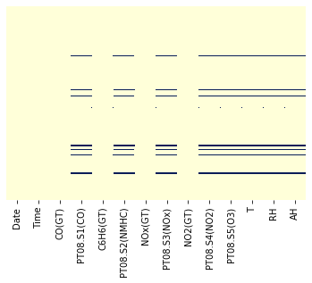

```python
sns.heatmap(df.isnull(),yticklabels=False,cbar=False,cmap='YlGnBu')
```

## Uzupełniam rekordy gdzie całe urządzenie pomiarowe nie pracowało.

Na rysunku widać to jako linie ciągłe.

```python
df.shape
```

```
(9357, 14)
```

```python
df.fillna(method='ffill', inplace=True)
```

```python
df.shape
```

```
(9357, 14)
```

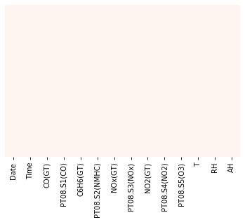

```python
sns.heatmap(df.isnull(),yticklabels=False,cbar=False,cmap='Reds')
```

```python
df.isnull().sum()
```

```
Date             0
Time             0
CO(GT)           0
PT08.S1(CO)      0
C6H6(GT)         0
PT08.S2(NMHC)    0
NOx(GT)          0
PT08.S3(NOx)     0
NO2(GT)          0
PT08.S4(NO2)     0
PT08.S5(O3)      0
T                0
RH               0
AH               0
dtype: int64
```

Dane zostały uzupełnione

Jak uzupełnić brakujące dane w dataframe Python?